# Naa10 het heart

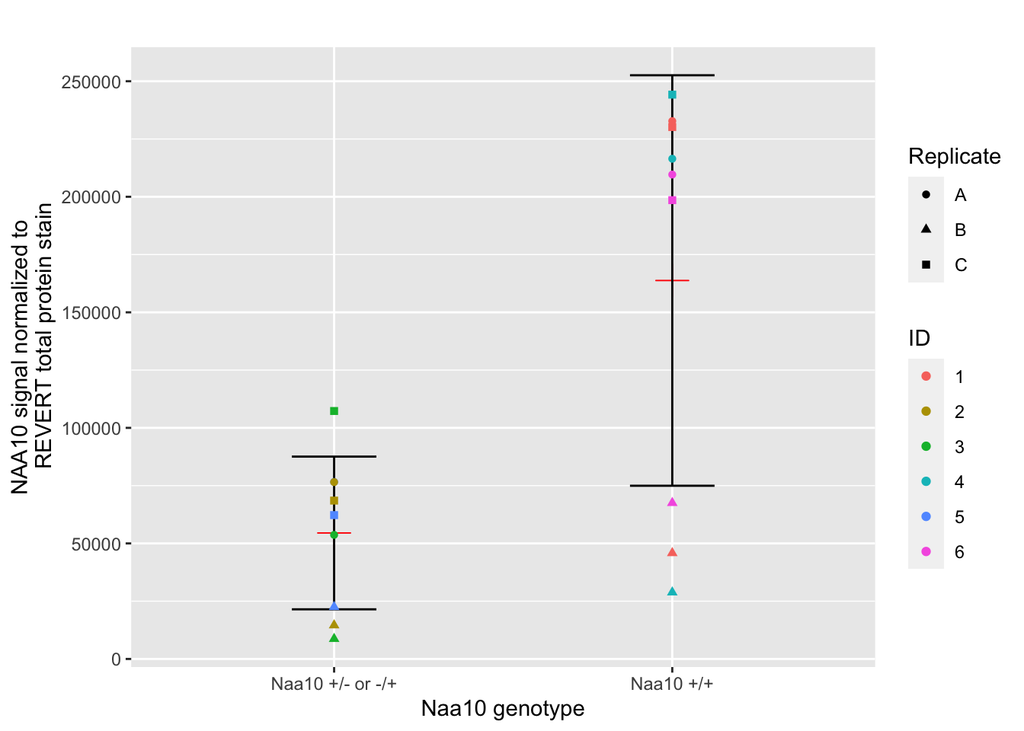

```r
ggplot(heart,aes(x = Genotype,
                 y = Normalized.Signal))+
  stat_summary(fun= mean, geom="point",
               shape=3, size=5, color="red", fill="black")+
  geom_errorbar(data = heart_sum1,
                aes(ymin = Normalized.Signal-sd,
                    ymax = Normalized.Signal+sd,
                    width = 0.25))+
  geom_point(aes(color = ID,
                 shape = Replicate),
             alpha = 1)+
  xlab("Naa10 genotype")+
  ylab("NAA10 signal normalized to
       REVERT total protein stain")+
  ggtitle("")
```

##main plot

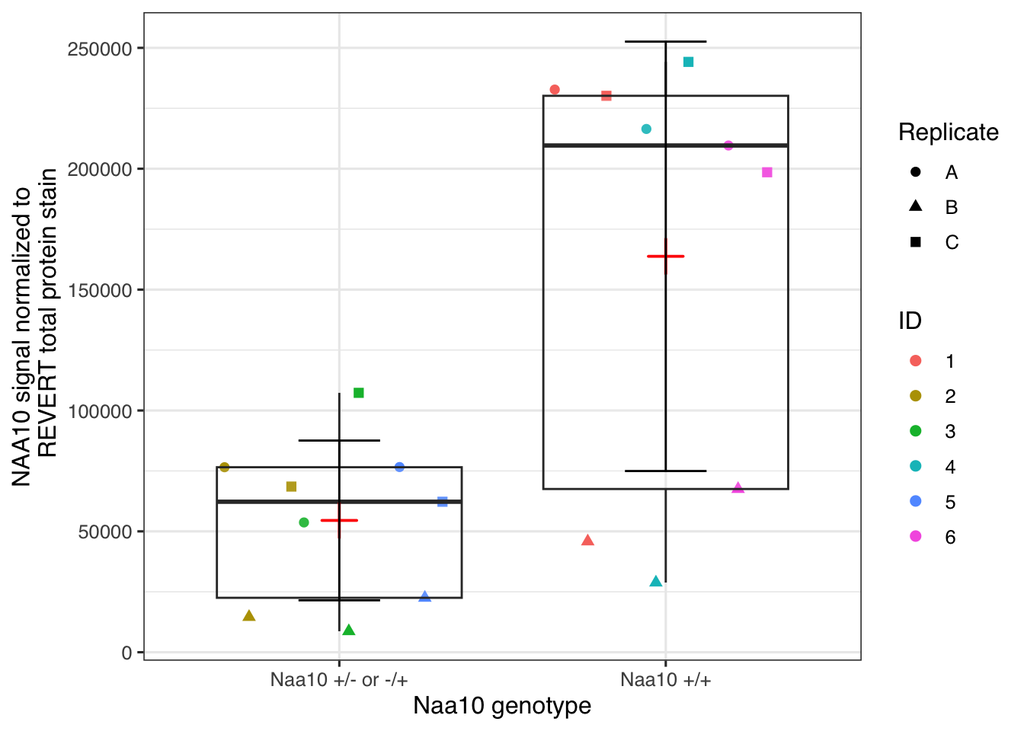

```r
#same plot as above, but with jitterd points
library(ggplot2)
ggplot(heart,aes(x = Genotype,
                 y = Normalized.Signal))+
  geom_point(aes(color = ID,
                 shape = Replicate),
             alpha = 2,
             size = 2,
                 position = position_jitterdodge())+
  geom_boxplot(outlier.shape = NA,
               alpha = 0.1)+
  stat_summary(fun= mean, geom="point",
               shape=3, size=5,stroke = 1,color="red", fill="black")+
  geom_errorbar(data = heart_sum1,
                aes(ymin = Normalized.Signal-sd,
                    ymax = Normalized.Signal+sd,
                    width = 0.25))+
  xlab("Naa10 genotype")+
  ylab("NAA10 signal normalized to
       REVERT total protein stain")+
  theme_bw(base_size = 12, base_family = "Helvetica")
```

May consider combining the liver and heart genotype data so I can plot genotype on X-axis and normalized NAA10 signal on Y-axis as usual. If I combine liver and heart, I can have 2 box plots on each genotype pertaining to organ.

#hypothesis testing ##parametric ###two-sample t-test null hypothesis: there is no mean difference in NAA10 signal between Naa10 female genotypes

Alternative: there is a difference in NAA10 signal between Naa10 female genotypes

```r
##Unpaired t-test of NAA10 signal grouped by Genotype
t.test(heart$Normalized.Signal~heart$Genotype,
       paired = F,
       var.equal = F)
```

```
##
##  Welch Two Sample t-test
##
## data:  heart$Normalized.Signal by heart$Genotype
## t = -3.4585, df = 10.173, p-value = 0.005986
## alternative hypothesis: true difference in means between group Naa10 +/- or -/+ and group Naa10 +/+ is not equal to 0
## 95 percent confidence interval:
##  -179467.51  -39026.63
## sample estimates:
## mean in group Naa10 +/- or -/+        mean in group Naa10 +/+
##                       54519.94                      163767.01
```

###differences between replicates Null hypothesis: there is no difference in NAA10 signal of individual hearts on replicate blots Alternative hypothesis: there is a difference in NAA10 signal of individual hearts on replicate blots

```r
install.packages("car",repos = "http://cran.us.r-project.org")
library(car)
heart.aov <- lm(Normalized.Signal~Replicate, heart)
summary(heart.aov)
```

```
##
## Call:
## lm(formula = Normalized.Signal ~ Replicate, data = heart)
##
## Residuals:
##    Min     1Q Median     3Q    Max
## -90587 -61884  -5657  60685  92369
##
## Coefficients:
##             Estimate Std. Error t value Pr(>|t|)
## (Intercept)   144273      28063   5.141 0.000121 ***
## ReplicateB   -112947      39687  -2.846 0.012267 *
## ReplicateC      7559      39687   0.190 0.851497
## ---
## Signif. codes:  0 '***' 0.001 '**' 0.01 '*' 0.05 '.' 0.1 ' ' 1
##
## Residual standard error: 68740 on 15 degrees of freedom
## Multiple R-squared:  0.4355, Adjusted R-squared:  0.3602
## F-statistic: 5.785 on 2 and 15 DF,  p-value: 0.01373
```

```r
Anova(heart.aov,type = "III")
```

```
## Anova Table (Type III tests)
##
## Response: Normalized.Signal
##                 Sum Sq Df F value    Pr(>F)
## (Intercept) 1.2489e+11  1 26.4304 0.0001206 ***
## Replicate   5.4671e+10  2  5.7852 0.0137312 *
## Residuals   7.0877e+10 15
## ---
## Signif. codes:  0 '***' 0.001 '**' 0.01 '*' 0.05 '.' 0.1 ' ' 1
```

###expanded model that may drive changes in Normalized Signal

```r
heart1.aov <- lm(Normalized.Signal~Replicate*Genotype,heart)

summary(heart1.aov)
```

```
##
## Call:
## lm(formula = Normalized.Signal ~ Replicate * Genotype, data = heart)
##
## Residuals:
##    Min     1Q Median     3Q    Max
## -25761 -10622  -1122   7646  27939
##
## Coefficients:
##                              Estimate Std. Error t value Pr(>|t|)
## (Intercept)                     68940      10226   6.741 2.07e-05 ***
## ReplicateB                     -53679      14462  -3.712  0.00297 **
## ReplicateC                      10419      14462   0.720  0.48506
## GenotypeNaa10 +/+              150665      14462  10.418 2.30e-07 ***
## ReplicateB:GenotypeNaa10 +/+  -118535      20453  -5.796 8.53e-05 ***
## ReplicateC:GenotypeNaa10 +/+    -5720      20453  -0.280  0.78449
## ---
## Signif. codes:  0 '***' 0.001 '**' 0.01 '*' 0.05 '.' 0.1 ' ' 1
##
## Residual standard error: 17710 on 12 degrees of freedom
## Multiple R-squared:   0.97,  Adjusted R-squared:  0.9575
## F-statistic: 77.63 on 5 and 12 DF,  p-value: 1.025e-08
```

```r
Anova(heart1.aov,type = "III")
```

```
## Anova Table (Type III tests)
##
## Response: Normalized.Signal
##                        Sum Sq Df F value    Pr(>F)
## (Intercept)        1.4258e+10  1  45.446 2.069e-05 ***
## Replicate          7.0986e+09  2  11.313 0.0017325 **
## Genotype           3.4050e+10  1 108.530 2.297e-07 ***
## Replicate:Genotype 1.3405e+10  2  21.363 0.0001111 ***
## Residuals          3.7649e+09 12
## ---
## Signif. codes:  0 '***' 0.001 '**' 0.01 '*' 0.05 '.' 0.1 ' ' 1
```

```r
#Wilcox test instead of Welch's t-test
wilcox.test(Normalized.Signal~Genotype,heart)
```

```
##
##  Wilcoxon rank sum exact test
##
## data:  Normalized.Signal by Genotype
## W = 16, p-value = 0.03147
## alternative hypothesis: true location shift is not equal to 0
```

p = 0.03; I reject the null hypothesis.

###Does replicate blot drive differences in NAA10 signal

```r
kruskal.test(Normalized.Signal~Replicate,heart)
```

```
##
##  Kruskal-Wallis rank sum test
##
## data:  Normalized.Signal by Replicate
## Kruskal-Wallis chi-squared = 10.152, df = 2, p-value = 0.006245
```

I reject the null hypothesis.

###does median NAA10 signal differ?

```r
install.packages("coin", repo ="http://cran.us.r-project.org")
library(coin)
median_test(Normalized.Signal~Genotype,heart)
```

```
##
##  Asymptotic Two-Sample Brown-Mood Median Test
##
## data:  Normalized.Signal by Genotype (Naa10 +/- or -/+, Naa10 +/+)
## Z = -1.3744, p-value = 0.1693
## alternative hypothesis: true mu is not equal to 0
```